# Boston Housing Regression Analysis

Abdullah Shahzad

2025-08-08

# Introduction

This report presents a detailed regression analysis of the **Boston Housing** dataset.  
The goal is to investigate how various housing characteristics affect the **median value of owner-occupied homes** (`medv`) in different suburbs of Boston.

We will:

1. Explore and visualize the dataset.
2. Identify key predictors of `medv`.
3. Fit and evaluate regression models (linear and polynomial).
4. Interpret the results and insights.

The dataset comes from the **MASS** package and contains 506 observations with 14 variables.

# Load Libraries and Data

```r
library(MASS)      # For Boston dataset
library(tidyverse) # Data manipulation and visualization
library(car)       # For VIF calculations
library(corrplot)  # For correlation plots
library(caret)     # For train-test splitting
```

```r
# Load the dataset
data("Boston")

# Quick look at the data
glimpse(Boston)
```

```
## Rows: 506
## Columns: 14
## $ crim    <dbl> 0.00632, 0.02731, 0.02729, 0.03237, 0.06905, 0.02985, 0.08829,…
## $ zn      <dbl> 18.0, 0.0, 0.0, 0.0, 0.0, 0.0, 12.5, 12.5, 12.5, 12.5, 12.5, 1…
## $ indus   <dbl> 2.31, 7.07, 7.07, 2.18, 2.18, 2.18, 7.87, 7.87, 7.87, 7.87, 7.…
## $ chas    <int> 0, 0, 0, 0, 0, 0, 0, 0, 0, 0, 0, 0, 0, 0, 0, 0, 0, 0, 0, 0, 0,…
## $ nox     <dbl> 0.538, 0.469, 0.469, 0.458, 0.458, 0.458, 0.524, 0.524, 0.524,…
## $ rm      <dbl> 6.575, 6.421, 7.185, 6.998, 7.147, 6.430, 6.012, 6.172, 5.631,…
## $ age     <dbl> 65.2, 78.9, 61.1, 45.8, 54.2, 58.7, 66.6, 96.1, 100.0, 85.9, 9…
## $ dis     <dbl> 4.0900, 4.9671, 4.9671, 6.0622, 6.0622, 6.0622, 5.5605, 5.9505…
## $ rad     <int> 1, 2, 2, 3, 3, 3, 5, 5, 5, 5, 5, 5, 5, 4, 4, 4, 4, 4, 4, 4, 4,…
## $ tax     <dbl> 296, 242, 242, 222, 222, 222, 311, 311, 311, 311, 311, 311, 31…
## $ ptratio <dbl> 15.3, 17.8, 17.8, 18.7, 18.7, 18.7, 15.2, 15.2, 15.2, 15.2, 15…
## $ black   <dbl> 396.90, 396.90, 392.83, 394.63, 396.90, 394.12, 395.60, 396.90…
## $ lstat   <dbl> 4.98, 9.14, 4.03, 2.94, 5.33, 5.21, 12.43, 19.15, 29.93, 17.10…
## $ medv    <dbl> 24.0, 21.6, 34.7, 33.4, 36.2, 28.7, 22.9, 27.1, 16.5, 18.9, 15…
```

```r
summary(Boston)
```

```
##       crim                zn             indus            chas
##  Min.   : 0.00632   Min.   :  0.00   Min.   : 0.46   Min.   :0.00000
##  1st Qu.: 0.08205   1st Qu.:  0.00   1st Qu.: 5.19   1st Qu.:0.00000
##  Median : 0.25651   Median :  0.00   Median : 9.69   Median :0.00000
##  Mean   : 3.61352   Mean   : 11.36   Mean   :11.14   Mean   :0.06917
##  3rd Qu.: 3.67708   3rd Qu.: 12.50   3rd Qu.:18.10   3rd Qu.:0.00000
##  Max.   :88.97620   Max.   :100.00   Max.   :27.74   Max.   :1.00000
##       nox               rm             age              dis
##  Min.   :0.3850   Min.   :3.561   Min.   :  2.90   Min.   : 1.130
##  1st Qu.:0.4490   1st Qu.:5.886   1st Qu.: 45.02   1st Qu.: 2.100
##  Median :0.5380   Median :6.208   Median : 77.50   Median : 3.207
##  Mean   :0.5547   Mean   :6.285   Mean   : 68.57   Mean   : 3.795
##  3rd Qu.:0.6240   3rd Qu.:6.623   3rd Qu.: 94.08   3rd Qu.: 5.188
##  Max.   :0.8710   Max.   :8.780   Max.   :100.00   Max.   :12.127
##       rad              tax           ptratio          black
##  Min.   : 1.000   Min.   :187.0   Min.   :12.60   Min.   :  0.32
##  1st Qu.: 4.000   1st Qu.:279.0   1st Qu.:17.40   1st Qu.:375.38
##  Median : 5.000   Median :330.0   Median :19.05   Median :391.44
##  Mean   : 9.549   Mean   :408.2   Mean   :18.46   Mean   :356.67
##  3rd Qu.:24.000   3rd Qu.:666.0   3rd Qu.:20.20   3rd Qu.:396.23
##  Max.   :24.000   Max.   :711.0   Max.   :22.00   Max.   :396.90
##      lstat            medv
##  Min.   : 1.73   Min.   : 5.00
##  1st Qu.: 6.95   1st Qu.:17.02
##  Median :11.36   Median :21.20
##  Mean   :12.65   Mean   :22.53
##  3rd Qu.:16.95   3rd Qu.:25.00
##  Max.   :37.97   Max.   :50.00
```

```r
# Check for missing values
colSums(is.na(Boston))
```

```
##    crim      zn   indus    chas     nox      rm     age     dis     rad     tax
##       0       0       0       0       0       0       0       0       0       0
## ptratio   black   lstat    medv
##       0       0       0       0
```

# Exploratory Data Analysis

## Correlation with Target Variable

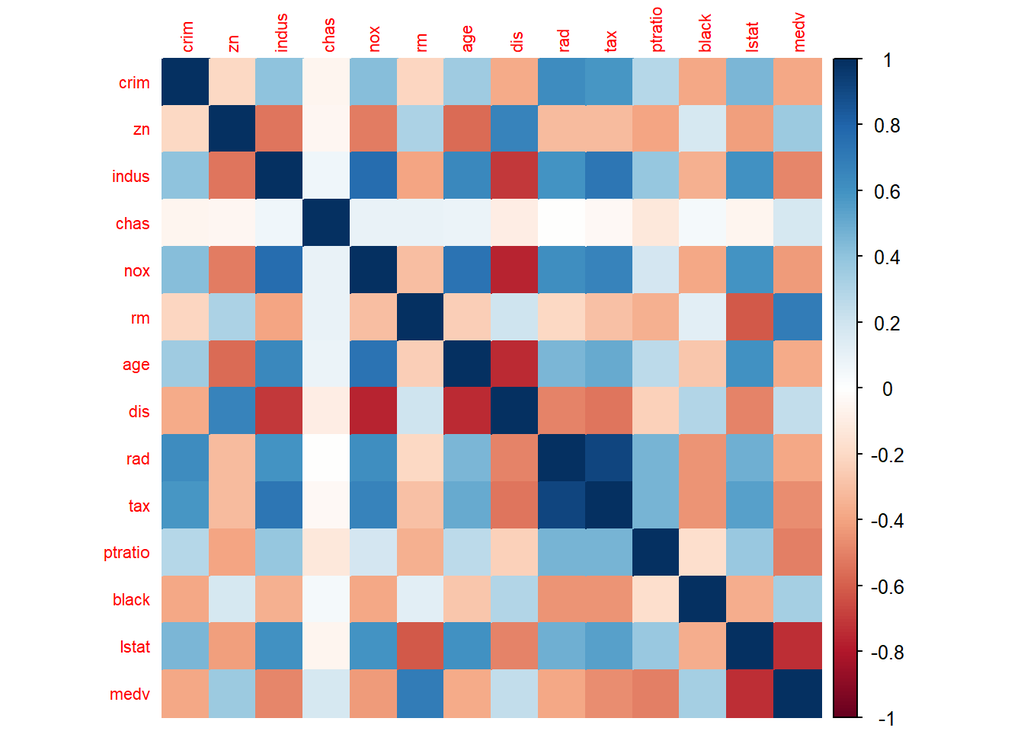

```r
corr_matrix <- cor(Boston)
corrplot(corr_matrix, method = "color", tl.cex = 0.7)
```

```r
sort(corr_matrix[, "medv"], decreasing = TRUE)
```

```
##       medv         rm         zn      black        dis       chas        age
##  1.0000000  0.6953599  0.3604453  0.3334608  0.2499287  0.1752602 -0.3769546
##        rad       crim        nox        tax      indus    ptratio      lstat
## -0.3816262 -0.3883046 -0.4273208 -0.4685359 -0.4837252 -0.5077867 -0.7376627
```

**Observation:**  
- `rm` (average number of rooms) has a strong positive correlation with `medv`.  
- `lstat` (% lower status) has a strong negative correlation.

## Distribution of Median Home Value

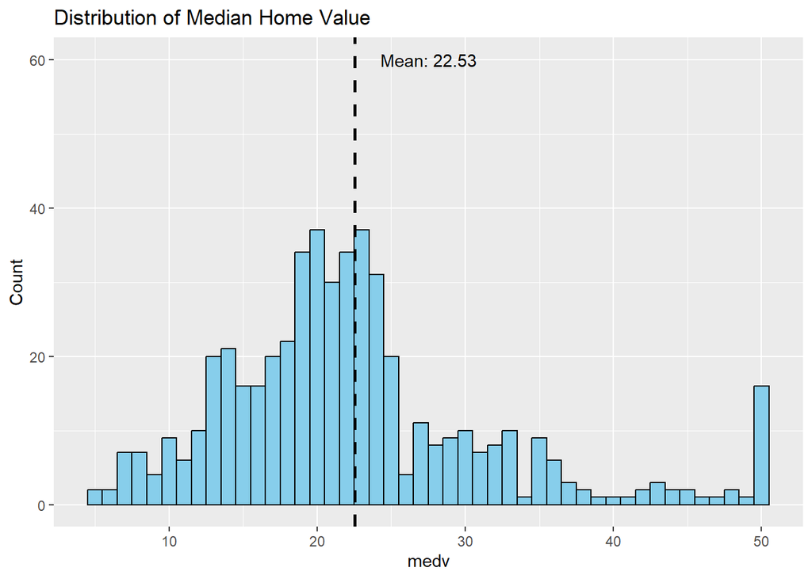

```r
Boston %>%
  ggplot(aes(x = medv)) +
  geom_histogram(binwidth = 1, fill = "skyblue", color = "black") +
  geom_vline(aes(xintercept = mean(medv)),
             linetype = "dashed", linewidth = 1) +
  annotate("text", x = mean(Boston$medv) + 5, y = 60,
           label = paste("Mean:", round(mean(Boston$medv), 2))) +
  labs(title = "Distribution of Median Home Value", x = "medv", y = "Count")
```

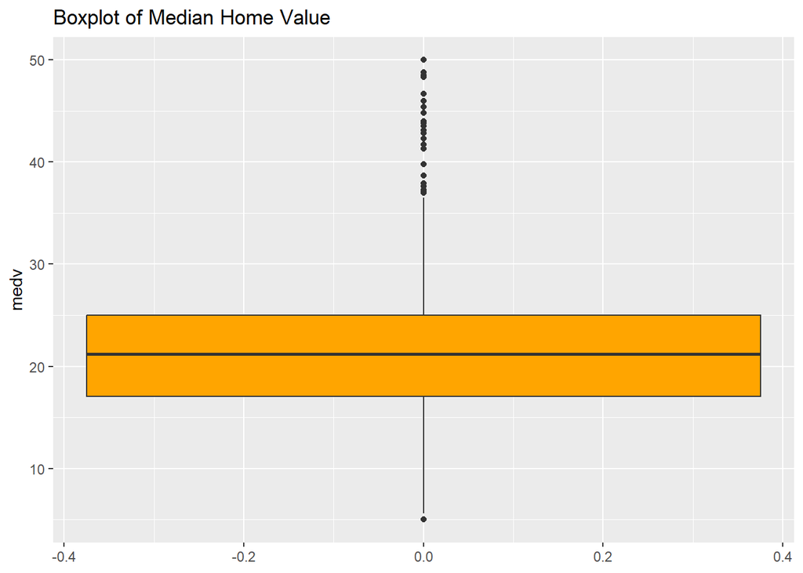

```r
Boston %>%
  ggplot(aes(y = medv)) +
  geom_boxplot(fill = "orange") +
  labs(title = "Boxplot of Median Home Value")
```

## Scatterplots for Key Variables

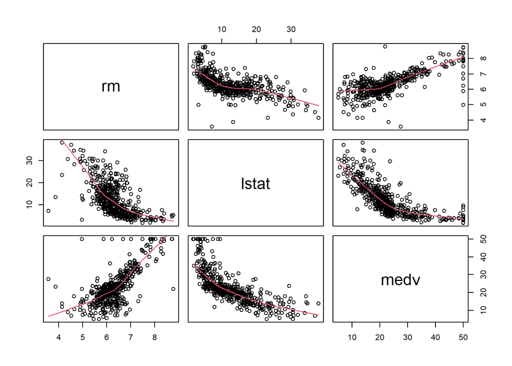

```r
pairs(~ rm + lstat + medv,
      data = Boston,
      panel = panel.smooth)
```

**Insights:** - `rm` vs `medv`: Strong linear relationship. - `lstat` vs `medv`: Downward curve, suggesting non-linearity. - `lstat` vs `rm`: Negative correlation.

# Model Building

## Model 1: Simple Multiple Linear Regression

```r
model1 <- lm(medv ~ rm + lstat, data = Boston)
summary(model1)
```

```
##
## Call:
## lm(formula = medv ~ rm + lstat, data = Boston)
##
## Residuals:
##     Min      1Q  Median      3Q     Max
## -18.076  -3.516  -1.010   1.909  28.131
##
## Coefficients:
##             Estimate Std. Error t value Pr(>|t|)
## (Intercept) -1.35827    3.17283  -0.428    0.669
## rm           5.09479    0.44447  11.463   <2e-16 ***
## lstat       -0.64236    0.04373 -14.689   <2e-16 ***
## ---
## Signif. codes:  0 '***' 0.001 '**' 0.01 '*' 0.05 '.' 0.1 ' ' 1
##
## Residual standard error: 5.54 on 503 degrees of freedom
## Multiple R-squared:  0.6386, Adjusted R-squared:  0.6371
## F-statistic: 444.3 on 2 and 503 DF,  p-value: < 2.2e-16
```

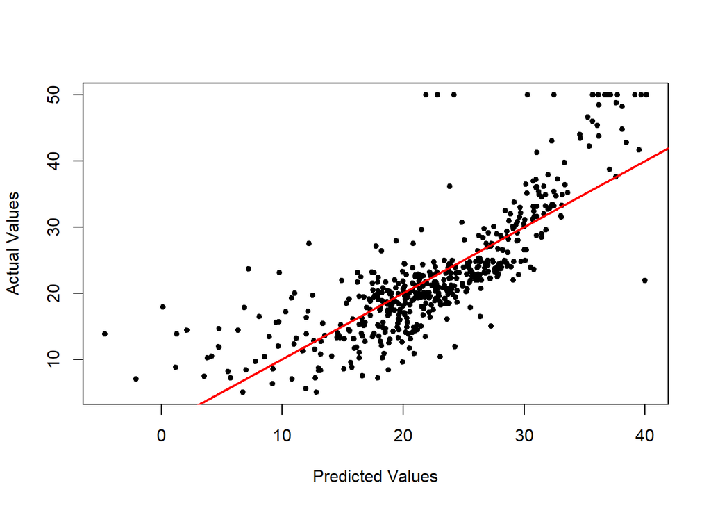

```r
# Plot predicted vs actual
pred <- predict(model1)
actual <- Boston$medv
plot(pred, actual, pch = 20,
     xlab = "Predicted Values", ylab = "Actual Values")
abline(0, 1, col = "red", lwd = 2)
```

**Observation:** Model explains ~64% of variance (R²), but struggles with extreme values.

## Model 2: Adding More Predictors

```r
model2 <- lm(medv ~ rm + lstat + ptratio + tax + black + crim, data = Boston)
summary(model2)
```

```
##
## Call:
## lm(formula = medv ~ rm + lstat + ptratio + tax + black + crim,
##     data = Boston)
##
## Residuals:
##      Min       1Q   Median       3Q      Max
## -14.8380  -3.1501  -0.9639   1.5767  30.3113
##
## Coefficients:
##               Estimate Std. Error t value Pr(>|t|)
## (Intercept) 11.6353689  4.2365863   2.746 0.006243 **
## rm           4.7788164  0.4269217  11.194  < 2e-16 ***
## lstat       -0.4993660  0.0482838 -10.342  < 2e-16 ***
## ptratio     -0.8903808  0.1239551  -7.183 2.49e-12 ***
## tax          0.0006655  0.0019624   0.339 0.734656
## black        0.0098124  0.0028953   3.389 0.000757 ***
## crim        -0.0432340  0.0339679  -1.273 0.203685
## ---
## Signif. codes:  0 '***' 0.001 '**' 0.01 '*' 0.05 '.' 0.1 ' ' 1
##
## Residual standard error: 5.162 on 499 degrees of freedom
## Multiple R-squared:  0.6888, Adjusted R-squared:  0.685
## F-statistic: 184.1 on 6 and 499 DF,  p-value: < 2.2e-16
```

```r
vif(model2)
```

```
##       rm    lstat  ptratio      tax    black     crim
## 1.705501 2.253446 1.365025 2.073430 1.324295 1.618112
```

**Observation:**  
- Some predictors (e.g., `tax`, `crim`) are not statistically significant. - Multicollinearity is present but manageable.

## Model 3: Removing Insignificant Predictors

```r
model3 <- lm(medv ~ rm + lstat + ptratio + black, data = Boston)
summary(model3)
```

```
##
## Call:
## lm(formula = medv ~ rm + lstat + ptratio + black, data = Boston)
##
## Residuals:
##      Min       1Q   Median       3Q      Max
## -14.6587  -3.0400  -0.9279   1.6649  30.2631
##
## Coefficients:
##              Estimate Std. Error t value Pr(>|t|)
## (Intercept) 12.054773   4.219677   2.857 0.004457 **
## rm           4.745826   0.424496  11.180  < 2e-16 ***
## lstat       -0.512543   0.044454 -11.530  < 2e-16 ***
## ptratio     -0.899037   0.116383  -7.725 6.15e-14 ***
## black        0.010457   0.002733   3.826 0.000147 ***
## ---
## Signif. codes:  0 '***' 0.001 '**' 0.01 '*' 0.05 '.' 0.1 ' ' 1
##
## Residual standard error: 5.16 on 501 degrees of freedom
## Multiple R-squared:  0.6877, Adjusted R-squared:  0.6853
## F-statistic: 275.9 on 4 and 501 DF,  p-value: < 2.2e-16
```

# Polynomial Regression for Non-Linearity

Since `lstat` shows curvature in its relationship with `medv`, we add a squared term.

```r
polymodel <- lm(medv ~ rm + lstat + I(lstat^2) + ptratio + black, data = Boston)
summary(polymodel)
```

```
##
## Call:
## lm(formula = medv ~ rm + lstat + I(lstat^2) + ptratio + black,
##     data = Boston)
##
## Residuals:
##      Min       1Q   Median       3Q      Max
## -15.4525  -2.7444  -0.5775   1.9967  28.6585
##
## Coefficients:
##              Estimate Std. Error t value Pr(>|t|)
## (Intercept) 19.876396   3.987769   4.984 8.58e-07 ***
## rm           4.091995   0.398410  10.271  < 2e-16 ***
## lstat       -1.576308   0.121256 -13.000  < 2e-16 ***
## I(lstat^2)   0.031394   0.003367   9.324  < 2e-16 ***
## ptratio     -0.706682   0.109486  -6.455 2.57e-10 ***
## black        0.009261   0.002528   3.663 0.000276 ***
## ---
## Signif. codes:  0 '***' 0.001 '**' 0.01 '*' 0.05 '.' 0.1 ' ' 1
##
## Residual standard error: 4.767 on 500 degrees of freedom
## Multiple R-squared:  0.734,  Adjusted R-squared:  0.7313
## F-statistic: 275.9 on 5 and 500 DF,  p-value: < 2.2e-16
```

```r
vif(polymodel)
```

```
##         rm      lstat I(lstat^2)    ptratio      black
##   1.741326  16.661450  14.038257   1.248527   1.184122
```

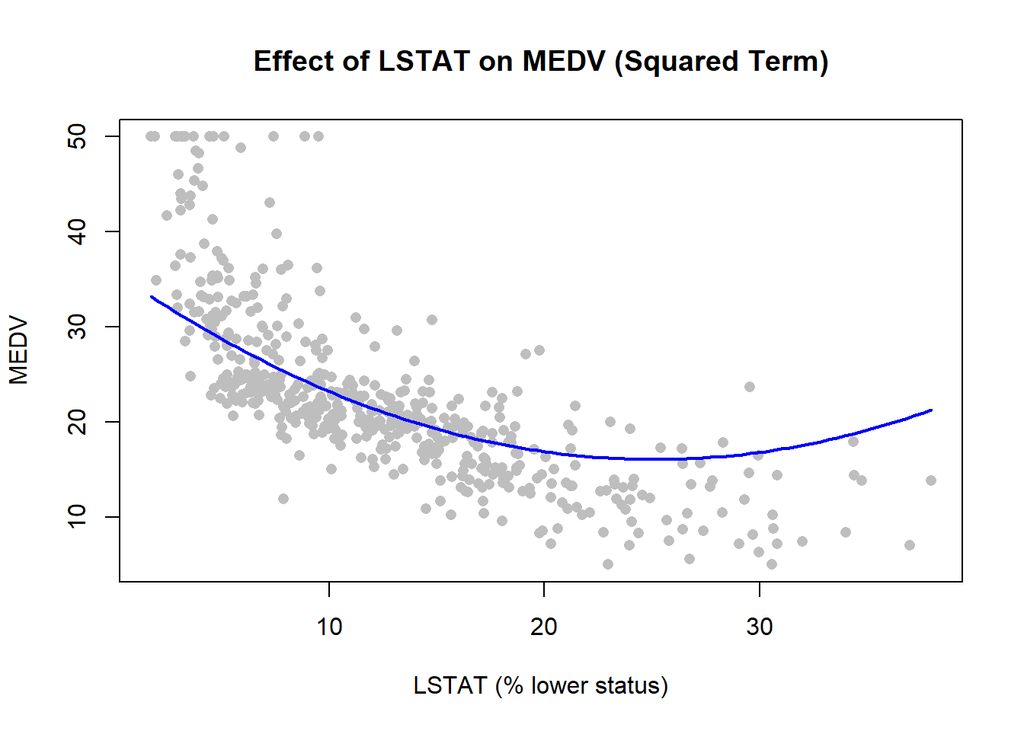

```r
lstat_vals <- seq(min(Boston$lstat), max(Boston$lstat), length.out = 100)
rm_mean <- mean(Boston$rm)
ptratio_mean <- mean(Boston$ptratio)
black_mean <- mean(Boston$black)

newdata <- data.frame(
  rm = rm_mean,
  lstat = lstat_vals,
  ptratio = ptratio_mean,
  black = black_mean
)

predicted_medv <- predict(polymodel, newdata = newdata)

plot(Boston$lstat, Boston$medv, pch = 16, col = "gray",
     xlab = "LSTAT (% lower status)", ylab = "MEDV",
     main = "Effect of LSTAT on MEDV (Squared Term)")
lines(lstat_vals, predicted_medv, col = "blue", lwd = 2)
```

## Polynomial on `rm` as Well

```r
poly2 <- lm(medv ~ rm + I(rm^2) + lstat + I(lstat^2) + ptratio + black, data = Boston)
summary(poly2)
```

```
##
## Call:
## lm(formula = medv ~ rm + I(rm^2) + lstat + I(lstat^2) + ptratio +
##     black, data = Boston)
##
## Residuals:
##      Min       1Q   Median       3Q      Max
## -26.6094  -2.3830  -0.4501   1.8871  28.7333
##
## Coefficients:
##               Estimate Std. Error t value Pr(>|t|)
## (Intercept) 107.048388   9.616428  11.132  < 2e-16 ***
## rm          -24.588649   2.949125  -8.338 7.43e-16 ***
## I(rm^2)       2.237820   0.228336   9.801  < 2e-16 ***
## lstat        -1.186988   0.118035 -10.056  < 2e-16 ***
## I(lstat^2)    0.018098   0.003371   5.368 1.22e-07 ***
## ptratio      -0.627567   0.100686  -6.233 9.75e-10 ***
## black         0.009276   0.002318   4.002 7.22e-05 ***
## ---
## Signif. codes:  0 '***' 0.001 '**' 0.01 '*' 0.05 '.' 0.1 ' ' 1
##
## Residual standard error: 4.37 on 499 degrees of freedom
## Multiple R-squared:  0.7769, Adjusted R-squared:  0.7743
## F-statistic: 289.7 on 6 and 499 DF,  p-value: < 2.2e-16
```

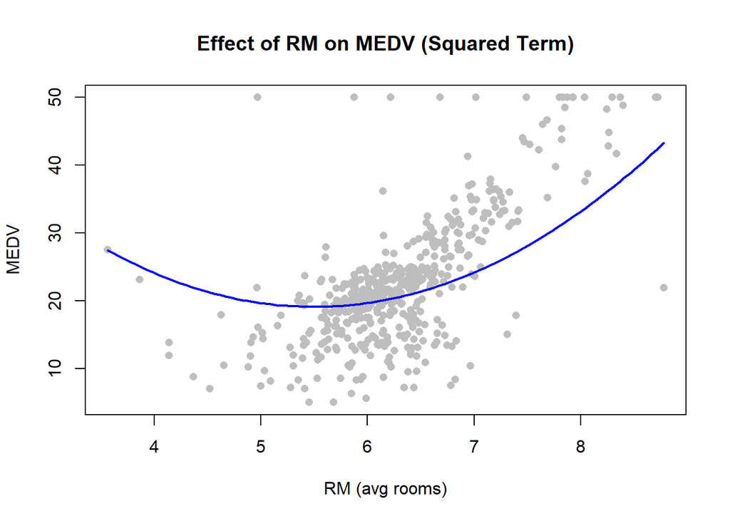

```r
rm_vals <- seq(min(Boston$rm), max(Boston$rm), length.out = 100)
lstat_mean <- mean(Boston$lstat)

newdata <- data.frame(
  lstat = lstat_mean,
  rm = rm_vals,
  ptratio = ptratio_mean,
  black = black_mean
)

predicted_medv <- predict(poly2, newdata = newdata)

plot(Boston$rm, Boston$medv, pch = 16, col = "gray",
     xlab = "RM (avg rooms)", ylab = "MEDV",
     main = "Effect of RM on MEDV (Squared Term)")
lines(rm_vals, predicted_medv, col = "blue", lwd = 2)
```

# Model Diagnostics

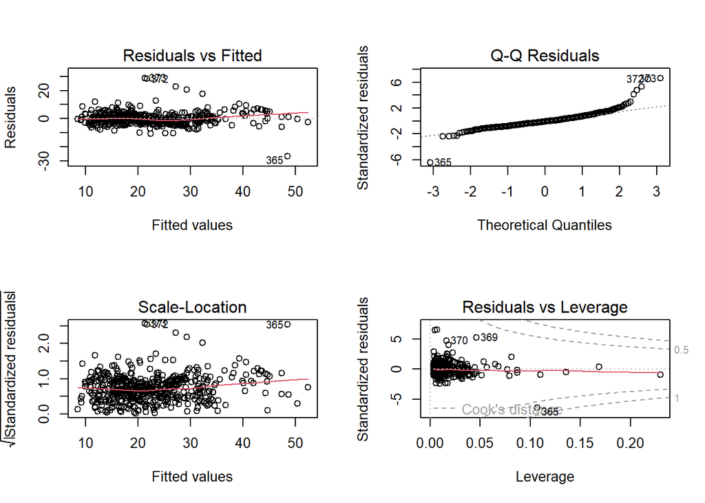

```r
par(mfrow = c(2, 2))
plot(poly2)
```

**Observations:** - Residuals show less curvature compared to earlier models. - Still some outliers at high `medv` values.

# Train-Test Evaluation

```r
set.seed(123)
train_index <- createDataPartition(Boston$medv, p = 0.8, list = FALSE)
train_data <- Boston[train_index, ]
test_data <- Boston[-train_index, ]

model_train <- lm(medv ~ rm + I(rm^2) + lstat + I(lstat^2) + ptratio + black,
                  data = train_data)

pred_train <- predict(model_train, newdata = train_data)
rmse_train <- sqrt(mean((pred_train - train_data$medv)^2))

pred_test <- predict(model_train, newdata = test_data)
rmse_test <- sqrt(mean((pred_test - test_data$medv)^2))

rmse_train
```

```
## [1] 4.343393
```

```r
rmse_test
```

```
## [1] 4.360338
```

# Conclusion

- `rm` and `lstat` are the strongest predictors of `medv`.
- Polynomial terms for `lstat` and `rm` improve model fit.
- Final polynomial multiple regression reduces error and captures curvature in the data.
- Caution: Model still struggles with extreme `medv` values, indicating potential need for robust regression or transformation.